# NBA_Expansion

This is a collaborative Tutorial created by Rishabh Baral and Christopher Adewunmi

### Part 1: Setting the Scene

In this tutorial, we will attempt to show prospective NBA owners which teams have spent well in the past and how, in today's money-driven NBA, to replicate their successes.

The first order of business for any new team is to be accepted entry to the league by the commissioner. Luckily, the ownership group has just recieved the following letter from commissioner Adam Silver:

Dear Seattle Ownership Group,

I am pleased to inform you that the NBA Board of Governors has approved your application to become an NBA team beginning in the 2023-24 season. We are thrilled to welcome you to the league and are excited about the potential for your city to become a great basketball market.

As you prepare for your inaugural season, please know that the NBA is committed to supporting you every step of the way. From marketing and ticket sales to player development and league operations, we will work closely with you to ensure your success both on and off the court.

Please take some time to review the league's rules and regulations, as well as our expectations for ownership and team management. We believe that your ownership group has the vision, expertise, and resources necessary to build a successful NBA franchise, and we look forward to seeing your team compete at the highest level.

Thank you for your commitment to the NBA, and we wish you all the best as you embark on this exciting new journey.

Sincerely,

Adam Silver NBA Commissioner

To celebrate their success, the ownership group has hired you as their manager of operations, the position handling team payroll and signings.

Your Offer Letter is as follows:

Dear Applicant,

We are pleased to offer you the position of Director of Operations for our new NBA team beginning in the 2023-24 season. The NBA Board of Governors has approved our application, and we are excited to welcome you to our organization.

Your experience and expertise make you an excellent fit for this role, and we believe you will be an integral part of our success. As Director of Operations, you will be responsible for overseeing the day-to-day activities of the team, including logistics, scheduling, and team travel.

We are committed to providing you with the support and resources necessary to excel in this role. From access to the best facilities and equipment to a talented and dedicated staff, we will work closely with you to ensure your success.

Please take some time to review the details of this offer, including the terms and conditions of your employment, salary and benefits, and other important information. We are confident that you will find this opportunity to be both challenging and rewarding.

Thank you for your interest in our organization, and we look forward to working with you as we build a successful NBA franchise.

Seattle Owneship Group]

### Part 2: Beginning your Duties

In order to start, the director of operations from the nearest team to you, Portland, has kindly linked you a CSV file with all the data he had collected.

His email to you reads as follows:

Dear Seattle Director of Operations,

I hope this email finds you well. I wanted to reach out to you regarding the upcoming NBA season and the exciting opportunity for our teams to work together.

As Director of Operations for the Portland TrailBlazers, I am excited to connect with you and your team. I believe that our organizations can learn from each other and collaborate on best practices for success.

To that end, I wanted to let you know that I will be sending you a CSV file in the coming days that contains team data from each season since 1985. This information will provide valuable insights into our team's history and strategies for success.

I look forward to hearing your thoughts and feedback on the data. Please let me know if you have any questions or if there is anything else I can do to support you and your team.

Thank you for your time, and I look forward to working witht you.

Be regards,

[Director of Operadtions, Portla TrailBlazers]

It's now been about two days since the email and he has sent you the CSV file.

### Part 3: Loading and Viewing the Data

We need to read the CSV. In order to do this, we will import a module called pandas. This can be abbreviated as pd when importing if needed.

```python
import pandas as pd
```

Now that we have access to all the functionalities of Pandas, we need a CSV reader. Luckily, there is one inbuilt in Pandas.

```python
NBA_Data = pd.read_csv("Team_Records_Original.csv")
```

Just to check, you can type in the name of the DataFrame you just made to get an idea of the data in it.

```python
NBA_Data
```

|  | Season | Lg | Team | W | L | W/L% | Finish | SRS | Pace | Rel_Pace | ORtg | Rel_ORtg | DRtg | Rel_DRtg | Playoffs | Coaches | Top WS |
| --- | --- | --- | --- | --- | --- | --- | --- | --- | --- | --- | --- | --- | --- | --- | --- | --- | --- |
| 0 | 2017-18 | NBA | Boston Celtics | 29 | 10 | 0.744 | 1 | 4.38 | 95.4 | -1.7 | 108.0 | 0.2 | 102.8 | -5.0 | NaN | B. Stevens (29-10) | K. Irving (5.7) |
| 1 | 2016-17 | NBA | Boston Celtics* | 53 | 29 | 0.646 | 1 | 2.25 | 96.8 | 0.4 | 111.2 | 2.4 | 108.4 | -0.4 | Lost E. Conf. Finals | B. Stevens (53-29) | I. Thomas (12.5) |
| 2 | 2015-16 | NBA | Boston Celtics* | 48 | 34 | 0.585 | 2 | 2.84 | 98.5 | 2.7 | 106.8 | 0.4 | 103.6 | -2.8 | Lost E. Conf. 1st Rnd. | B. Stevens (48-34) | I. Thomas (9.7) |
| 3 | 2014-15 | NBA | Boston Celtics* | 40 | 42 | 0.488 | 2 | -0.40 | 95.8 | 1.9 | 104.7 | -0.9 | 104.5 | -1.1 | Lost E. Conf. 1st Rnd. | B. Stevens (40-42) | T. Zeller (6.5) |
| 4 | 2013-14 | NBA | Boston Celtics | 25 | 57 | 0.305 | 4 | -4.97 | 93.3 | -0.6 | 102.9 | -3.8 | 107.7 | 1.0 | NaN | B. Stevens (25-57) | B. Bass (5.1) |
| ... | ... | ... | ... | ... | ... | ... | ... | ... | ... | ... | ... | ... | ... | ... | ... | ... | ... |
| 1478 | 1999-00 | NBA | Vancouver Grizzlies | 22 | 60 | 0.268 | 7 | -5.10 | 91.0 | -2.1 | 102.3 | -1.8 | 108.5 | 4.4 | NaN | B. Hill (4-18) L. Hollins (18-42) | S. Abdur-Rahim (8.8) |
| 1479 | 1998-99 | NBA | Vancouver Grizzlies | 8 | 42 | 0.160 | 7 | -8.94 | 89.0 | 0.1 | 98.4 | -3.8 | 107.9 | 5.7 | NaN | B. Hill (8-42) | S. Abdur-Rahim (4.6) |
| 1480 | 1997-98 | NBA | Vancouver Grizzlies | 19 | 63 | 0.232 | 6 | -7.47 | 92.1 | 1.8 | 104.1 | -0.9 | 112.0 | 7.0 | NaN | B. Hill (19-63) | S. Abdur-Rahim (6.9) |
| 1481 | 1996-97 | NBA | Vancouver Grizzlies | 14 | 68 | 0.171 | 7 | -10.17 | 88.4 | -1.7 | 100.3 | -6.4 | 111.8 | 5.1 | NaN | B. Winters (8-35) S. Jackson (6-33) | G. Anthony (3.5) |
| 1482 | 1995-96 | NBA | Vancouver Grizzlies | 15 | 67 | 0.183 | 7 | -9.55 | 91.0 | -0.8 | 97.6 | -10.0 | 108.5 | 0.9 | NaN | B. Winters (15-67) | G. Anthony (4.8) |

1483 rows × 17 columns

Let's now tidy the data.

Firstly, lets sort the sheet by year.

```python
NBA_Data.sort_values(by = "Season")
```

|  | Season | Lg | Team | W | L | W/L% | Finish | SRS | Pace | Rel_Pace | ORtg | Rel_ORtg | DRtg | Rel_DRtg | Playoffs | Coaches | Top WS |
| --- | --- | --- | --- | --- | --- | --- | --- | --- | --- | --- | --- | --- | --- | --- | --- | --- | --- |
| 852 | 1946-47 | BAA | Philadelphia Warriors* | 35 | 25 | 0.583 | 2 | 3.16 | NaN | NaN | NaN | NaN | NaN | NaN | Won Finals | E. Gottlieb (35-25) | J. Fulks (16.3) |
| 71 | 1946-47 | BAA | Boston Celtics | 22 | 38 | 0.367 | 5 | -4.45 | NaN | NaN | NaN | NaN | NaN | NaN | NaN | J. Russell (22-38) | C. Simmons (6.1) |
| 166 | 1946-47 | BAA | New York Knicks* | 33 | 27 | 0.550 | 3 | 0.58 | NaN | NaN | NaN | NaN | NaN | NaN | Lost Semis | N. Cohalan (33-27) | O. Schectman (4.3) |
| 70 | 1947-48 | BAA | Boston Celtics* | 20 | 28 | 0.417 | 3 | -3.76 | NaN | NaN | NaN | NaN | NaN | NaN | Lost Quarterfinals | J. Russell (20-28) | E. Sadowski (9.3) |
| 851 | 1947-48 | BAA | Philadelphia Warriors* | 27 | 21 | 0.563 | 1 | 0.69 | NaN | NaN | NaN | NaN | NaN | NaN | Lost Finals | E. Gottlieb (27-21) | H. Dallmar (7.0) |
| ... | ... | ... | ... | ... | ... | ... | ... | ... | ... | ... | ... | ... | ... | ... | ... | ... | ... |
| 1406 | 2017-18 | NBA | New Orleans Pelicans | 18 | 17 | 0.514 | 3 | 0.33 | 99.8 | 2.7 | 110.6 | 2.8 | 110.6 | 2.8 | NaN | A. Gentry (18-17) | A. Davis (5.5) |
| 167 | 2017-18 | NBA | Philadelphia 76ers | 15 | 19 | 0.441 | 4 | -0.08 | 100.8 | 3.7 | 105.8 | -2.0 | 106.8 | -1.0 | NaN | B. Brown (15-19) | J. Embiid (2.6) |
| 1422 | 2017-18 | NBA | Dallas Mavericks | 12 | 25 | 0.324 | 4 | -1.59 | 95.0 | -2.1 | 105.6 | -2.2 | 108.2 | 0.4 | NaN | R. Carlisle (12-25) | D. Nowitzki (2.4) |
| 95 | 2017-18 | NBA | New York Knicks | 17 | 18 | 0.486 | 3 | -0.19 | 96.0 | -1.1 | 107.6 | -0.2 | 107.7 | -0.1 | NaN | J. Hornacek (17-18) | E. Kanter (3.7) |
| 0 | 2017-18 | NBA | Boston Celtics | 29 | 10 | 0.744 | 1 | 4.38 | 95.4 | -1.7 | 108.0 | 0.2 | 102.8 | -5.0 | NaN | B. Stevens (29-10) | K. Irving (5.7) |

1483 rows × 17 columns

Let's drop the BAA Data first,

```python
NBA_Data= NBA_Data.query("Lg != 'BAA'")
```

Then all years before 1985-86, because there is no salary data for these years,

```python
NBA_Data = NBA_Data.drop(NBA_Data[(NBA_Data.Season < "1985-86")].index)
```

```python
NBA_Data.sort_values(by = ["Season", "Team"])
```

|  | Season | Lg | Team | W | L | W/L% | Finish | SRS | Pace | Rel_Pace | ORtg | Rel_ORtg | DRtg | Rel_DRtg | Playoffs | Coaches | Top WS |
| --- | --- | --- | --- | --- | --- | --- | --- | --- | --- | --- | --- | --- | --- | --- | --- | --- | --- |
| 1267 | 1985-86 | NBA | Atlanta Hawks* | 50 | 32 | 0.610 | 2 | 2.59 | 100.0 | -2.1 | 107.9 | 0.7 | 105.6 | -1.6 | Lost E. Conf. Semis | M. Fratello (50-32) | D. Wilkins (10.8) |
| 32 | 1985-86 | NBA | Boston Celtics* | 67 | 15 | 0.817 | 1 | 9.06 | 101.2 | -0.9 | 111.8 | 4.6 | 102.6 | -4.6 | Won Finals | K. Jones (67-15) | L. Bird (15.8) |
| 761 | 1985-86 | NBA | Chicago Bulls* | 30 | 52 | 0.366 | 4 | -3.12 | 99.7 | -2.4 | 108.6 | 1.4 | 112.4 | 5.2 | Lost E. Conf. 1st Rnd. | S. Albeck (30-52) | O. Woolridge (5.6) |
| 542 | 1985-86 | NBA | Cleveland Cavaliers | 29 | 53 | 0.354 | 5 | -2.19 | 101.6 | -0.5 | 105.5 | -1.7 | 108.3 | 1.1 | NaN | G. Karl (25-42) G. Littles (4-11) | R. Hinson (7.4) |
| 1454 | 1985-86 | NBA | Dallas Mavericks* | 44 | 38 | 0.537 | 3 | 0.70 | 102.2 | 0.1 | 112.1 | 4.9 | 111.0 | 3.8 | Lost W. Conf. Semis | D. Motta (44-38) | S. Perkins (7.3) |
| ... | ... | ... | ... | ... | ... | ... | ... | ... | ... | ... | ... | ... | ... | ... | ... | ... | ... |
| 951 | 2017-18 | NBA | Sacramento Kings | 12 | 23 | 0.343 | 4 | -8.02 | 94.2 | -2.9 | 102.7 | -5.1 | 111.7 | 3.9 | NaN | D. Joerger (12-23) | Z. Randolph (1.7) |
| 1355 | 2017-18 | NBA | San Antonio Spurs | 25 | 11 | 0.694 | 2 | 3.03 | 94.5 | -2.6 | 107.7 | -0.1 | 104.0 | -3.8 | NaN | G. Popovich (25-11) | L. Aldridge (5.0) |
| 72 | 2017-18 | NBA | Toronto Raptors | 24 | 10 | 0.706 | 2 | 7.07 | 98.1 | 1.0 | 112.8 | 5.0 | 104.8 | -3.0 | NaN | D. Casey (24-10) | D. DeRozan (4.7) |
| 466 | 2017-18 | NBA | Utah Jazz | 15 | 21 | 0.417 | 5 | 0.53 | 94.9 | -2.2 | 106.3 | -1.5 | 106.8 | -1.0 | NaN | Q. Snyder (15-21) | D. Favors (3.0) |
| 1091 | 2017-18 | NBA | Washington Wizards | 20 | 16 | 0.556 | 1 | 1.64 | 97.2 | 0.1 | 108.5 | 0.7 | 106.3 | -1.5 | NaN | S. Brooks (20-16) | O. Porter (4.0) |

937 rows × 17 columns

And Lastly, there is no salary data for the for 89-90 season or the 86-87 season. Thus, we need to drop these sets of rows.

```python
NBA_Data = NBA_Data.drop(NBA_Data[(NBA_Data.Season == "1989-90")|(NBA_Data.Season=="1986-87")].index)
```

```python
NBA_Data.sort_values(by = ["Season", "Team"])
```

|  | Season | Lg | Team | W | L | W/L% | Finish | SRS | Pace | Rel_Pace | ORtg | Rel_ORtg | DRtg | Rel_DRtg | Playoffs | Coaches | Top WS |
| --- | --- | --- | --- | --- | --- | --- | --- | --- | --- | --- | --- | --- | --- | --- | --- | --- | --- |
| 1267 | 1985-86 | NBA | Atlanta Hawks* | 50 | 32 | 0.610 | 2 | 2.59 | 100.0 | -2.1 | 107.9 | 0.7 | 105.6 | -1.6 | Lost E. Conf. Semis | M. Fratello (50-32) | D. Wilkins (10.8) |
| 32 | 1985-86 | NBA | Boston Celtics* | 67 | 15 | 0.817 | 1 | 9.06 | 101.2 | -0.9 | 111.8 | 4.6 | 102.6 | -4.6 | Won Finals | K. Jones (67-15) | L. Bird (15.8) |
| 761 | 1985-86 | NBA | Chicago Bulls* | 30 | 52 | 0.366 | 4 | -3.12 | 99.7 | -2.4 | 108.6 | 1.4 | 112.4 | 5.2 | Lost E. Conf. 1st Rnd. | S. Albeck (30-52) | O. Woolridge (5.6) |
| 542 | 1985-86 | NBA | Cleveland Cavaliers | 29 | 53 | 0.354 | 5 | -2.19 | 101.6 | -0.5 | 105.5 | -1.7 | 108.3 | 1.1 | NaN | G. Karl (25-42) G. Littles (4-11) | R. Hinson (7.4) |
| 1454 | 1985-86 | NBA | Dallas Mavericks* | 44 | 38 | 0.537 | 3 | 0.70 | 102.2 | 0.1 | 112.1 | 4.9 | 111.0 | 3.8 | Lost W. Conf. Semis | D. Motta (44-38) | S. Perkins (7.3) |
| ... | ... | ... | ... | ... | ... | ... | ... | ... | ... | ... | ... | ... | ... | ... | ... | ... | ... |
| 951 | 2017-18 | NBA | Sacramento Kings | 12 | 23 | 0.343 | 4 | -8.02 | 94.2 | -2.9 | 102.7 | -5.1 | 111.7 | 3.9 | NaN | D. Joerger (12-23) | Z. Randolph (1.7) |
| 1355 | 2017-18 | NBA | San Antonio Spurs | 25 | 11 | 0.694 | 2 | 3.03 | 94.5 | -2.6 | 107.7 | -0.1 | 104.0 | -3.8 | NaN | G. Popovich (25-11) | L. Aldridge (5.0) |
| 72 | 2017-18 | NBA | Toronto Raptors | 24 | 10 | 0.706 | 2 | 7.07 | 98.1 | 1.0 | 112.8 | 5.0 | 104.8 | -3.0 | NaN | D. Casey (24-10) | D. DeRozan (4.7) |
| 466 | 2017-18 | NBA | Utah Jazz | 15 | 21 | 0.417 | 5 | 0.53 | 94.9 | -2.2 | 106.3 | -1.5 | 106.8 | -1.0 | NaN | Q. Snyder (15-21) | D. Favors (3.0) |
| 1091 | 2017-18 | NBA | Washington Wizards | 20 | 16 | 0.556 | 1 | 1.64 | 97.2 | 0.1 | 108.5 | 0.7 | 106.3 | -1.5 | NaN | S. Brooks (20-16) | O. Porter (4.0) |

887 rows × 17 columns

We did, by accident, have our final result on hand, so lets just make some quick modifications to this one using that file

```python
team_data = pd.read_csv("Team_Records.csv")
```

We have two tables of different sizes, so we need to merge some of the end rows of the Tidied table with those in the Messy table.

```python
NBA_Data = NBA_Data.drop(NBA_Data.columns[[6, 7, 8, 9, 10, 11, 12, 13, 14, 15, 16]], axis=1)
```

```python
NBA_Data.sort_values("Team")
```

|  | Season | Lg | Team | W | L | W/L% |
| --- | --- | --- | --- | --- | --- | --- |
| 1249 | 2003-04 | NBA | Atlanta Hawks | 28 | 54 | 0.341 |
| 1252 | 2000-01 | NBA | Atlanta Hawks | 25 | 57 | 0.305 |
| 1248 | 2004-05 | NBA | Atlanta Hawks | 13 | 69 | 0.159 |
| 1247 | 2005-06 | NBA | Atlanta Hawks | 26 | 56 | 0.317 |
| 1246 | 2006-07 | NBA | Atlanta Hawks | 30 | 52 | 0.366 |
| ... | ... | ... | ... | ... | ... | ... |
| 1102 | 2006-07 | NBA | Washington Wizards* | 41 | 41 | 0.500 |
| 1101 | 2007-08 | NBA | Washington Wizards* | 43 | 39 | 0.524 |
| 1095 | 2013-14 | NBA | Washington Wizards* | 44 | 38 | 0.537 |
| 1094 | 2014-15 | NBA | Washington Wizards* | 46 | 36 | 0.561 |
| 1092 | 2016-17 | NBA | Washington Wizards* | 49 | 33 | 0.598 |

887 rows × 6 columns

```python
team_data
```

|  | Season (identified by Start Year) | Lg | Team | Abbreviation | Conf | W | L | Win_Pct | Payroll | Made Playoffs (Play-In Included) |
| --- | --- | --- | --- | --- | --- | --- | --- | --- | --- | --- |
| 0 | 1985 | NBA | Atlanta Hawks | ATL | East | 50 | 32 | 0.610 | 3671250.0 | Yes |
| 1 | 1985 | NBA | Boston Celtics | BOS | East | 67 | 15 | 0.817 | 6560000.0 | Yes |
| 2 | 1985 | NBA | Chicago Bulls | CHI | East | 30 | 52 | 0.366 | 4486000.0 | Yes |
| 3 | 1985 | NBA | Cleveland Cavaliers | CLE | East | 29 | 53 | 0.354 | 3920666.0 | No |
| 4 | 1985 | NBA | Dallas Mavericks | DAL | West | 44 | 38 | 0.537 | 4052346.0 | Yes |
| ... | ... | ... | ... | ... | ... | ... | ... | ... | ... | ... |
| 1032 | 2022 | NBA | Sacramento Kings | SAC | West | 48 | 34 | 0.585 | 139423615.0 | Yes |
| 1033 | 2022 | NBA | San Antonio Spurs | SAS | West | 22 | 60 | 0.268 | 104545376.0 | No |
| 1034 | 2022 | NBA | Toronto Raptors | TOR | East | 41 | 41 | 0.500 | 150992313.0 | Yes |
| 1035 | 2022 | NBA | Utah Jazz | UTA | West | 37 | 45 | 0.451 | 148738241.0 | No |
| 1036 | 2022 | NBA | Washington Wizards | WSH | East | 35 | 47 | 0.427 | 152008934.0 | No |

1037 rows × 10 columns

```python
frames = NBA_Data, team_data
NBA_Data = pd.concat(frames)
```

```python
NBA_Data
```

|  | Season | Lg | Team | W | L | W/L% | Season (identified by Start Year) | Abbreviation | Conf | Win_Pct | Payroll | Made Playoffs (Play-In Included) |
| --- | --- | --- | --- | --- | --- | --- | --- | --- | --- | --- | --- | --- |
| 0 | 2017-18 | NBA | Boston Celtics | 29 | 10 | 0.744 | NaN | NaN | NaN | NaN | NaN | NaN |
| 1 | 2016-17 | NBA | Boston Celtics* | 53 | 29 | 0.646 | NaN | NaN | NaN | NaN | NaN | NaN |
| 2 | 2015-16 | NBA | Boston Celtics* | 48 | 34 | 0.585 | NaN | NaN | NaN | NaN | NaN | NaN |
| 3 | 2014-15 | NBA | Boston Celtics* | 40 | 42 | 0.488 | NaN | NaN | NaN | NaN | NaN | NaN |
| 4 | 2013-14 | NBA | Boston Celtics | 25 | 57 | 0.305 | NaN | NaN | NaN | NaN | NaN | NaN |
| ... | ... | ... | ... | ... | ... | ... | ... | ... | ... | ... | ... | ... |
| 1032 | NaN | NBA | Sacramento Kings | 48 | 34 | NaN | 2022.0 | SAC | West | 0.585 | 139423615.0 | Yes |
| 1033 | NaN | NBA | San Antonio Spurs | 22 | 60 | NaN | 2022.0 | SAS | West | 0.268 | 104545376.0 | No |
| 1034 | NaN | NBA | Toronto Raptors | 41 | 41 | NaN | 2022.0 | TOR | East | 0.500 | 150992313.0 | Yes |
| 1035 | NaN | NBA | Utah Jazz | 37 | 45 | NaN | 2022.0 | UTA | West | 0.451 | 148738241.0 | No |
| 1036 | NaN | NBA | Washington Wizards | 35 | 47 | NaN | 2022.0 | WSH | East | 0.427 | 152008934.0 | No |

1924 rows × 12 columns

```python
NBA_Data = NBA_Data[NBA_Data['Season (identified by Start Year)'].notna()]
```

```python
NBA_Data.drop(columns = ['W/L%'])
```

|  | Season | Lg | Team | W | L | Season (identified by Start Year) | Abbreviation | Conf | Win_Pct | Payroll | Made Playoffs (Play-In Included) |
| --- | --- | --- | --- | --- | --- | --- | --- | --- | --- | --- | --- |
| 0 | NaN | NBA | Atlanta Hawks | 50 | 32 | 1985.0 | ATL | East | 0.610 | 3671250.0 | Yes |
| 1 | NaN | NBA | Boston Celtics | 67 | 15 | 1985.0 | BOS | East | 0.817 | 6560000.0 | Yes |
| 2 | NaN | NBA | Chicago Bulls | 30 | 52 | 1985.0 | CHI | East | 0.366 | 4486000.0 | Yes |
| 3 | NaN | NBA | Cleveland Cavaliers | 29 | 53 | 1985.0 | CLE | East | 0.354 | 3920666.0 | No |
| 4 | NaN | NBA | Dallas Mavericks | 44 | 38 | 1985.0 | DAL | West | 0.537 | 4052346.0 | Yes |
| ... | ... | ... | ... | ... | ... | ... | ... | ... | ... | ... | ... |
| 1032 | NaN | NBA | Sacramento Kings | 48 | 34 | 2022.0 | SAC | West | 0.585 | 139423615.0 | Yes |
| 1033 | NaN | NBA | San Antonio Spurs | 22 | 60 | 2022.0 | SAS | West | 0.268 | 104545376.0 | No |
| 1034 | NaN | NBA | Toronto Raptors | 41 | 41 | 2022.0 | TOR | East | 0.500 | 150992313.0 | Yes |
| 1035 | NaN | NBA | Utah Jazz | 37 | 45 | 2022.0 | UTA | West | 0.451 | 148738241.0 | No |
| 1036 | NaN | NBA | Washington Wizards | 35 | 47 | 2022.0 | WSH | East | 0.427 | 152008934.0 | No |

1037 rows × 11 columns

Finally we have tidied our data, but we must make two more changes. Firstly, we must remove the blank "Season" Column. Then, we must change the Season (identified by Start Year) to be Season and be int data.

```python
NBA_Data = NBA_Data.drop(columns = ['Season'])
```

Just for better understanding, let's rename the Seasons column.

```python
NBA_Data = NBA_Data.drop(NBA_Data.columns[[4]], axis=1)
```

Let's move the Season column to the beginning so that it's clearer.

```python
column_to_move = NBA_Data.pop("Season (identified by Start Year)")
```

```python
NBA_Data.insert(0, "Season", column_to_move)
```

```python
NBA_Data.Season = NBA_Data.Season.astype(int)
```

```python
NBA_Data
```

|  | Season | Lg | Team | W | L | Abbreviation | Conf | Win_Pct | Payroll | Made Playoffs (Play-In Included) |
| --- | --- | --- | --- | --- | --- | --- | --- | --- | --- | --- |
| 0 | 1985 | NBA | Atlanta Hawks | 50 | 32 | ATL | East | 0.610 | 3671250.0 | Yes |
| 1 | 1985 | NBA | Boston Celtics | 67 | 15 | BOS | East | 0.817 | 6560000.0 | Yes |
| 2 | 1985 | NBA | Chicago Bulls | 30 | 52 | CHI | East | 0.366 | 4486000.0 | Yes |
| 3 | 1985 | NBA | Cleveland Cavaliers | 29 | 53 | CLE | East | 0.354 | 3920666.0 | No |
| 4 | 1985 | NBA | Dallas Mavericks | 44 | 38 | DAL | West | 0.537 | 4052346.0 | Yes |
| ... | ... | ... | ... | ... | ... | ... | ... | ... | ... | ... |
| 1032 | 2022 | NBA | Sacramento Kings | 48 | 34 | SAC | West | 0.585 | 139423615.0 | Yes |
| 1033 | 2022 | NBA | San Antonio Spurs | 22 | 60 | SAS | West | 0.268 | 104545376.0 | No |
| 1034 | 2022 | NBA | Toronto Raptors | 41 | 41 | TOR | East | 0.500 | 150992313.0 | Yes |
| 1035 | 2022 | NBA | Utah Jazz | 37 | 45 | UTA | West | 0.451 | 148738241.0 | No |
| 1036 | 2022 | NBA | Washington Wizards | 35 | 47 | WSH | East | 0.427 | 152008934.0 | No |

1037 rows × 10 columns

And now that we have cleaned our data, we can use it for analysis.

### Part 4: Performing Exploratory Data Analysis (Splitting, Collating, and Graphing)

Now, in order to perform an analysis that processes the data through time, we need to split the data into groups.

We will do this with pandas' cut function. This function will help us by creating however many groups we specify (5 in this case).

```python
NBA_Data['bins'] = pd.cut(x = NBA_Data['Season'], bins = 5)
```

If we type in the name of our dataframe, we can see that there is a new column indicating the group that each data point belongs to.

```python
NBA_Data
```

|  | Season | Lg | Team | W | L | Abbreviation | Conf | Win_Pct | Payroll | Made Playoffs (Play-In Included) | bins |
| --- | --- | --- | --- | --- | --- | --- | --- | --- | --- | --- | --- |
| 0 | 1985 | NBA | Atlanta Hawks | 50 | 32 | ATL | East | 0.610 | 3671250.0 | Yes | (1984.963, 1992.4] |
| 1 | 1985 | NBA | Boston Celtics | 67 | 15 | BOS | East | 0.817 | 6560000.0 | Yes | (1984.963, 1992.4] |
| 2 | 1985 | NBA | Chicago Bulls | 30 | 52 | CHI | East | 0.366 | 4486000.0 | Yes | (1984.963, 1992.4] |
| 3 | 1985 | NBA | Cleveland Cavaliers | 29 | 53 | CLE | East | 0.354 | 3920666.0 | No | (1984.963, 1992.4] |
| 4 | 1985 | NBA | Dallas Mavericks | 44 | 38 | DAL | West | 0.537 | 4052346.0 | Yes | (1984.963, 1992.4] |
| ... | ... | ... | ... | ... | ... | ... | ... | ... | ... | ... | ... |
| 1032 | 2022 | NBA | Sacramento Kings | 48 | 34 | SAC | West | 0.585 | 139423615.0 | Yes | (2014.6, 2022.0] |
| 1033 | 2022 | NBA | San Antonio Spurs | 22 | 60 | SAS | West | 0.268 | 104545376.0 | No | (2014.6, 2022.0] |
| 1034 | 2022 | NBA | Toronto Raptors | 41 | 41 | TOR | East | 0.500 | 150992313.0 | Yes | (2014.6, 2022.0] |
| 1035 | 2022 | NBA | Utah Jazz | 37 | 45 | UTA | West | 0.451 | 148738241.0 | No | (2014.6, 2022.0] |
| 1036 | 2022 | NBA | Washington Wizards | 35 | 47 | WSH | East | 0.427 | 152008934.0 | No | (2014.6, 2022.0] |

1037 rows × 11 columns

To make plotting easier, lets first take a look at how many data points fall into each group.

This can be done using the "value_counts" function applied to the dataframe column of interest, Bins in this case.

```python
team_data_bins = NBA_Data.bins.value_counts().sort_index()
```

To then see these counts, we can apply the same logic as with the dataframe, typing in the variable name in order to see the data stored.

```python
team_data_bins
```

```
bins
(1984.963, 1992.4]    152
(1992.4, 1999.8]      199
(1999.8, 2007.2]      236
(2007.2, 2014.6]      210
(2014.6, 2022.0]      240
Name: count, dtype: int64
```

Now that we know how many of our 1037 data points fall into each category, we can begin splitting the table into minitables, one for each period. This will make analysis infinitely easier and will allow us to see a comparison between teams in each period, separately.

```python
team_data_period_1 = NBA_Data.iloc[:152, :10]
```

```python
team_data_period_1
```

|  | Season | Lg | Team | W | L | Abbreviation | Conf | Win_Pct | Payroll | Made Playoffs (Play-In Included) |
| --- | --- | --- | --- | --- | --- | --- | --- | --- | --- | --- |
| 0 | 1985 | NBA | Atlanta Hawks | 50 | 32 | ATL | East | 0.610 | 3671250.0 | Yes |
| 1 | 1985 | NBA | Boston Celtics | 67 | 15 | BOS | East | 0.817 | 6560000.0 | Yes |
| 2 | 1985 | NBA | Chicago Bulls | 30 | 52 | CHI | East | 0.366 | 4486000.0 | Yes |
| 3 | 1985 | NBA | Cleveland Cavaliers | 29 | 53 | CLE | East | 0.354 | 3920666.0 | No |
| 4 | 1985 | NBA | Dallas Mavericks | 44 | 38 | DAL | West | 0.537 | 4052346.0 | Yes |
| ... | ... | ... | ... | ... | ... | ... | ... | ... | ... | ... |
| 147 | 1992 | NBA | Sacramento Kings | 25 | 57 | SAC | West | 0.305 | 13953000.0 | No |
| 148 | 1992 | NBA | San Antonio Spurs | 49 | 33 | SAS | West | 0.598 | 18083000.0 | Yes |
| 149 | 1992 | NBA | Seattle SuperSonics | 55 | 27 | SEA | West | 0.671 | 14033000.0 | Yes |
| 150 | 1992 | NBA | Utah Jazz | 47 | 35 | UTA | West | 0.573 | 14517000.0 | Yes |
| 151 | 1992 | NBA | Washington Bullets | 22 | 60 | WAS | East | 0.268 | 17249000.0 | No |

152 rows × 10 columns

Now the problem is that the data spans 8 years in the first bin. As such, teams are repeated. We don't want to have multiple points for the same team, so we need to find the Unique Team Names.

In order to do so, we will use the columnar "unique" function available for Pandas DataFrames.

```python
teams_1 = team_data_period_1['Abbreviation'].unique()
```

Now we need to create a mini-array of the data we just extracted from the table. Let's use a loop over all the teams, adding the necessary info to a blank array.

The array we create here will come in handy later when we analyze the data and eventually plot it.

```python
team_period_1 = []
for abbrev in teams_1:
    team_period_1.append(team_data_period_1[team_data_period_1.Abbreviation == abbrev])
```

Now that we have an array, we need to create a dataframe that we can use for plotting later.

```python
team_data_1 = pd.concat(team_period_1)
```

Since there are roughly 8 years of data in each bin, we need to look at averages from the 8 year period. We will do this by calling the columnar "mean" function on the colums labeled Win % and Payroll.

```python
mean_payroll_per_team_1 = []
mean_winning_pct_per_team_1 = []
for abbrev in teams_1:
    mean_payroll_per_team_1.append(team_data_1.loc[team_data_1['Abbreviation'] == abbrev, 'Payroll'].mean())
    mean_winning_pct_per_team_1.append(team_data_1.loc[team_data_1['Abbreviation'] == abbrev, 'Win_Pct'].mean())
```

Now that we have calculated the averages for 'Payroll' and 'W/L%' over the first period, we can now make a smaller dataframe solely for this period in the data.

```python
team_avgs_period_1 = pd.DataFrame()
team_avgs_period_1['Team'] = teams_1
team_avgs_period_1['Mean Payroll'] = mean_payroll_per_team_1
team_avgs_period_1['Mean Winning Percentage'] = mean_winning_pct_per_team_1
```

And now that we have a dataframe containing the data we need from this time period, we can plot the data to see which teams were especially efficient.

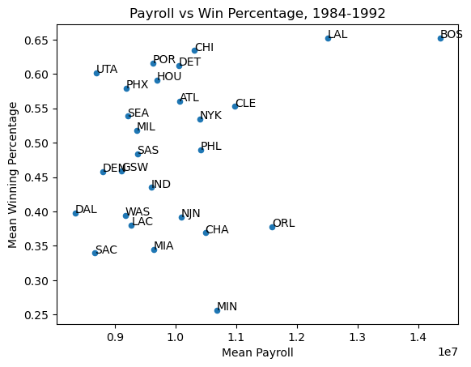

```python
period_1_NBA = team_avgs_period_1.plot(kind = 'scatter', title = "Payroll vs Win Percentage, 1984-1992", x = 'Mean Payroll', y = 'Mean Winning Percentage')
for idx, row in team_avgs_period_1.iterrows():
    period_1_NBA.annotate(row['Team'], (row['Mean Payroll'], row['Mean Winning Percentage']))
```

In order to continue to analyze, we can repeat the process that we just did to analyze the first period, we can repeat the same process for each of the remaining 4 periods.

```python
team_data_period_2 = NBA_Data.iloc[152:351, :10]
```

```python
teams_2 = team_data_period_2['Abbreviation'].unique()
```

```python
team_period_2 = []
for abbrev in teams_2:
    team_period_2.append(team_data_period_2[team_data_period_2.Abbreviation == abbrev])
```

```python
team_data_2 = pd.concat(team_period_2)
```

```python
mean_payroll_per_team_2 = []
mean_winning_pct_per_team_2 = []
for abbrev in teams_2:
    mean_payroll_per_team_2.append(team_data_2.loc[team_data_2['Abbreviation'] == abbrev, 'Payroll'].mean())
    mean_winning_pct_per_team_2.append(team_data_2.loc[team_data_2['Abbreviation'] == abbrev, 'Win_Pct'].mean())
```

```python
team_avgs_period_2 = pd.DataFrame()
team_avgs_period_2['Team'] = teams_2
team_avgs_period_2['Mean Payroll'] = mean_payroll_per_team_2
team_avgs_period_2['Mean Winning Percentage'] = mean_winning_pct_per_team_2
```

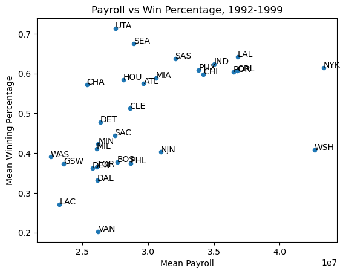

```python
period_2_NBA = team_avgs_period_2.plot(kind = 'scatter', title = "Payroll vs Win Percentage, 1992-1999", x = 'Mean Payroll', y = 'Mean Winning Percentage')
for idx, row in team_avgs_period_2.iterrows():
     period_2_NBA.annotate(row['Team'], (row['Mean Payroll'], row['Mean Winning Percentage']))
```

```python
team_data_period_3 = NBA_Data.iloc[351:586, :10]
```

```python
teams_3 = team_data_period_3['Abbreviation'].unique()
```

```python
team_period_3 = []
for abbrev in teams_3:
    team_period_3.append(team_data_period_3[team_data_period_3.Abbreviation == abbrev])
```

```python
team_data_3 = pd.concat(team_period_3)
```

```python
mean_payroll_per_team_3 = []
mean_winning_pct_per_team_3 = []
for abbrev in teams_3:
    mean_payroll_per_team_3.append(team_data_3.loc[team_data_3['Abbreviation'] == abbrev, 'Payroll'].mean())
    mean_winning_pct_per_team_3.append(team_data_3.loc[team_data_3['Abbreviation'] == abbrev, 'Win_Pct'].mean())
```

```python
team_avgs_period_3 = pd.DataFrame()
team_avgs_period_3['Team'] = teams_3
team_avgs_period_3['Mean Payroll'] = mean_payroll_per_team_3
team_avgs_period_3['Mean Winning Percentage'] = mean_winning_pct_per_team_3
```

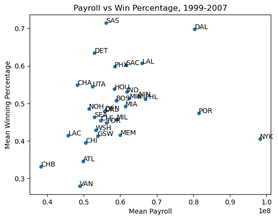

```python
period_3_NBA = team_avgs_period_3.plot(kind = 'scatter', title = "Payroll vs Win Percentage, 1999-2007", x = 'Mean Payroll', y = 'Mean Winning Percentage')
for idx, row in team_avgs_period_3.iterrows():
     period_3_NBA.annotate(row['Team'], (row['Mean Payroll'], row['Mean Winning Percentage']))
```

```python
team_data_period_4 = NBA_Data.iloc[586:797, :10]
```

```python
teams_4 = team_data_period_4['Abbreviation'].unique()
```

```python
team_period_4 = []
for abbrev in teams_4:
    team_period_4.append(team_data_period_4[team_data_period_4.Abbreviation == abbrev])
```

```python
team_data_4 = pd.concat(team_period_4)
```

```python
mean_payroll_per_team_4 = []
mean_winning_pct_per_team_4 = []
for abbrev in teams_4:
    mean_payroll_per_team_4.append(team_data_4.loc[team_data_4['Abbreviation'] == abbrev, 'Payroll'].mean())
    mean_winning_pct_per_team_4.append(team_data_4.loc[team_data_4['Abbreviation'] == abbrev, 'Win_Pct'].mean())
```

```python
team_avgs_period_4 = pd.DataFrame()
team_avgs_period_4['Team'] = teams_4
team_avgs_period_4['Mean Payroll'] = mean_payroll_per_team_4
team_avgs_period_4['Mean Winning Percentage'] = mean_winning_pct_per_team_4
```

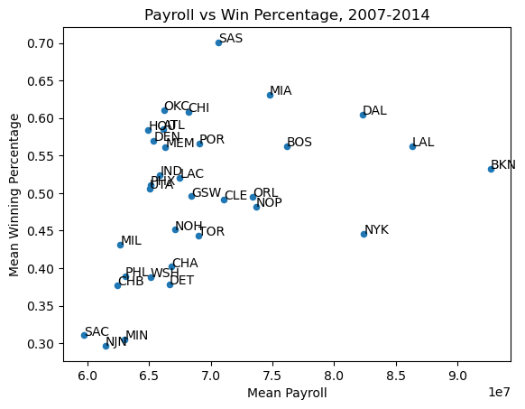

```python
period_4_NBA = team_avgs_period_4.plot(kind = 'scatter', title = "Payroll vs Win Percentage, 2007-2014", x = 'Mean Payroll', y = 'Mean Winning Percentage')
for idx, row in team_avgs_period_4.iterrows():
     period_4_NBA.annotate(row['Team'], (row['Mean Payroll'], row['Mean Winning Percentage']))
```

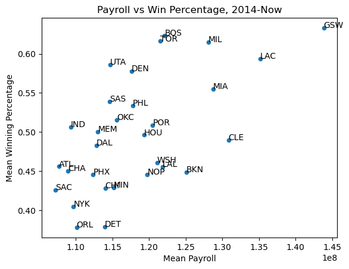

```python
##Extracting the rows from the table (NBA_Data)
team_data_period_5 = NBA_Data.iloc[797:, :10]

##Categorizing Data by team Abbreviation for easier processing
teams_5 = team_data_period_5['Abbreviation'].unique()

#processing the data, first by creating an array...
team_period_5 = []
for abbrev in teams_5:
    team_period_5.append(team_data_period_5[team_data_period_5.Abbreviation == abbrev])

##...then by creating a second array to hold the data.
team_data_5 = pd.concat(team_period_5)

#calculating the mean win percentage and mean payroll for each team over this period
mean_payroll_per_team_5 = []
mean_winning_pct_per_team_5 = []
for abbrev in teams_5:
    mean_payroll_per_team_5.append(team_data_5.loc[team_data_5['Abbreviation'] == abbrev, 'Payroll'].mean())
    mean_winning_pct_per_team_5.append(team_data_5.loc[team_data_5['Abbreviation'] == abbrev, 'Win_Pct'].mean())

##Creating a dataframe to hold all the data as needed
team_avgs_period_5 = pd.DataFrame()
team_avgs_period_5['Team'] = teams_5
team_avgs_period_5['Mean Payroll'] = mean_payroll_per_team_5
team_avgs_period_5['Mean Winning Percentage'] = mean_winning_pct_per_team_5

#plotting the data to show trends. (Should be no points because no data entered for this period yet.)
period_5_NBA = team_avgs_period_5.plot(kind = 'scatter', title = "Payroll vs Win Percentage, 2014-Now", x = 'Mean Payroll', y = 'Mean Winning Percentage')
for idx, row in team_avgs_period_5.iterrows():
     period_5_NBA.annotate(row['Team'], (row['Mean Payroll'], row['Mean Winning Percentage']))
```

### Part 5: Analyzing on a level playing field

The American Currency is a volatile one, rising and falling year in and year out. In order to make our analysis more accurate and possibly provide a better recommendation, we need to standardize the payrolls so that the early years and later years are treated similarly.

```python
years = NBA_Data['Season'].unique()
```

```python
years
```

```
array([1985, 1987, 1988, 1990, 1991, 1992, 1993, 1994, 1995, 1996, 1997,
       1998, 1999, 2000, 2001, 2002, 2003, 2004, 2005, 2006, 2007, 2008,
       2009, 2010, 2011, 2012, 2013, 2014, 2015, 2016, 2017, 2018, 2019,
       2020, 2021, 2022])
```

```python
teams = NBA_Data['Abbreviation'].unique()
```

```python
teams
```

```
array(['ATL', 'BOS', 'CHI', 'CLE', 'DAL', 'DEN', 'DET', 'GSW', 'HOU',
       'IND', 'LAC', 'LAL', 'MIL', 'NJN', 'NYK', 'PHL', 'PHX', 'POR',
       'SAC', 'SAS', 'SEA', 'UTA', 'WAS', 'CHA', 'MIA', 'MIN', 'ORL',
       'TOR', 'VAN', 'WSH', 'MEM', 'NOH', 'CHB', 'OKC', 'BKN', 'NOP'],
      dtype=object)
```

Now that we have the teams and years that were present in the original dataset, we can now attempt to standardize the payroll column.

```python
yearly_average_payroll = []
yearly_payroll_sd = []
annual_payroll_by_team = []
for year in NBA_Data['Season']:
    yearly_average_payroll.append(NBA_Data.loc[NBA_Data['Season'] == year, 'Payroll'].mean())
    yearly_payroll_sd.append(NBA_Data.loc[NBA_Data['Season'] == year, 'Payroll'].std())
    for abbrev in NBA_Data['Abbreviation']:
        annual_payroll_by_team.append(NBA_Data.loc[(NBA_Data['Season'] == year) & (NBA_Data['Abbreviation'] == abbrev), 'Payroll'])
```

```python
standardized_team_data = pd.concat([team_data_1, team_data_2, team_data_3, team_data_4, team_data_5])
```

The formula we will apply to standardize payroll is: $(payroll - payroll_j)/(sd_j)$ where $j$ represents the year

```python
standardized_team_data['yearly_average'] = yearly_average_payroll
standardized_team_data['yearly_standard_deviation'] = yearly_payroll_sd
standardized_team_data['Standardized Payroll'] =  (standardized_team_data['Payroll'] - standardized_team_data['yearly_average'])/standardized_team_data['yearly_standard_deviation']
```

Now that we have a column for standardized payroll, let's replot the data based on our improved table.

```python
standardized_team_data.sort_values(by = ['Season', 'Team'])
```

|  | Season | Lg | Team | W | L | Abbreviation | Conf | Win_Pct | Payroll | Made Playoffs (Play-In Included) | yearly_average | yearly_standard_deviation | Standardized Payroll |
| --- | --- | --- | --- | --- | --- | --- | --- | --- | --- | --- | --- | --- | --- |
| 0 | 1985 | NBA | Atlanta Hawks | 50 | 32 | ATL | East | 0.610 | 3671250.0 | Yes | 4.774809e+06 | 1.426164e+06 | -0.773795 |
| 1 | 1985 | NBA | Boston Celtics | 67 | 15 | BOS | East | 0.817 | 6560000.0 | Yes | 4.774809e+06 | 1.426164e+06 | 1.251744 |
| 2 | 1985 | NBA | Chicago Bulls | 30 | 52 | CHI | East | 0.366 | 4486000.0 | Yes | 4.774809e+06 | 1.426164e+06 | -0.202508 |
| 3 | 1985 | NBA | Cleveland Cavaliers | 29 | 53 | CLE | East | 0.354 | 3920666.0 | No | 4.774809e+06 | 1.426164e+06 | -0.598910 |
| 4 | 1985 | NBA | Dallas Mavericks | 44 | 38 | DAL | West | 0.537 | 4052346.0 | Yes | 6.049518e+06 | 1.261000e+06 | -1.583800 |
| ... | ... | ... | ... | ... | ... | ... | ... | ... | ... | ... | ... | ... | ... |
| 1032 | 2022 | NBA | Sacramento Kings | 48 | 34 | SAC | West | 0.585 | 139423615.0 | Yes | 1.373934e+08 | 1.889484e+07 | 0.107449 |
| 1033 | 2022 | NBA | San Antonio Spurs | 22 | 60 | SAS | West | 0.268 | 104545376.0 | No | 1.517126e+08 | 2.083672e+07 | -2.263657 |
| 1034 | 2022 | NBA | Toronto Raptors | 41 | 41 | TOR | East | 0.500 | 150992313.0 | Yes | 1.517126e+08 | 2.083672e+07 | -0.034566 |
| 1035 | 2022 | NBA | Utah Jazz | 37 | 45 | UTA | West | 0.451 | 148738241.0 | No | 1.517126e+08 | 2.083672e+07 | -0.142744 |
| 1036 | 2022 | NBA | Washington Wizards | 35 | 47 | WSH | East | 0.427 | 152008934.0 | No | 1.517126e+08 | 2.083672e+07 | 0.014224 |

1037 rows × 13 columns

With our new table of standardized data, we need to repeat the process we did to plot the raw data, but with the standardized data.

```python
standardized_team_data['bins'] = pd.cut(x = standardized_team_data['Season'], bins = 5)
```

```python
standardized_team_data
```

|  | Season | Lg | Team | W | L | Abbreviation | Conf | Win_Pct | Payroll | Made Playoffs (Play-In Included) | yearly_average | yearly_standard_deviation | Standardized Payroll | bins |
| --- | --- | --- | --- | --- | --- | --- | --- | --- | --- | --- | --- | --- | --- | --- |
| 0 | 1985 | NBA | Atlanta Hawks | 50 | 32 | ATL | East | 0.610 | 3671250.0 | Yes | 4.774809e+06 | 1.426164e+06 | -0.773795 | (1984.963, 1992.4] |
| 23 | 1987 | NBA | Atlanta Hawks | 50 | 32 | ATL | East | 0.610 | 6584200.0 | Yes | 4.774809e+06 | 1.426164e+06 | 1.268712 | (1984.963, 1992.4] |
| 46 | 1988 | NBA | Atlanta Hawks | 52 | 30 | ATL | East | 0.634 | 7382500.0 | Yes | 4.774809e+06 | 1.426164e+06 | 1.828466 | (1984.963, 1992.4] |
| 71 | 1990 | NBA | Atlanta Hawks | 43 | 39 | ATL | East | 0.524 | 11761000.0 | Yes | 4.774809e+06 | 1.426164e+06 | 4.898590 | (1984.963, 1992.4] |
| 98 | 1991 | NBA | Atlanta Hawks | 38 | 44 | ATL | East | 0.463 | 12930000.0 | No | 4.774809e+06 | 1.426164e+06 | 5.718272 | (1984.963, 1992.4] |
| ... | ... | ... | ... | ... | ... | ... | ... | ... | ... | ... | ... | ... | ... | ... |
| 916 | 2018 | NBA | Washington Wizards | 32 | 50 | WSH | East | 0.390 | 123747588.0 | No | 1.517126e+08 | 2.083672e+07 | -1.342101 | (2014.6, 2022.0] |
| 946 | 2019 | NBA | Washington Wizards | 25 | 47 | WSH | East | 0.347 | 121296256.0 | No | 1.517126e+08 | 2.083672e+07 | -1.459745 | (2014.6, 2022.0] |
| 976 | 2020 | NBA | Washington Wizards | 34 | 38 | WSH | East | 0.472 | 131294012.0 | Yes | 1.517126e+08 | 2.083672e+07 | -0.979931 | (2014.6, 2022.0] |
| 1006 | 2021 | NBA | Washington Wizards | 35 | 47 | WSH | East | 0.427 | 128019760.0 | No | 1.517126e+08 | 2.083672e+07 | -1.137070 | (2014.6, 2022.0] |
| 1036 | 2022 | NBA | Washington Wizards | 35 | 47 | WSH | East | 0.427 | 152008934.0 | No | 1.517126e+08 | 2.083672e+07 | 0.014224 | (2014.6, 2022.0] |

1037 rows × 14 columns

Since we are essentially repeating the process we had done with the initial data, just for the new standardized metrics, we need to first see how we should split up the table.

```python
team_data_bins = standardized_team_data.bins.value_counts().sort_index()
```

```python
team_data_bins
```

```
bins
(1984.963, 1992.4]    152
(1992.4, 1999.8]      199
(1999.8, 2007.2]      236
(2007.2, 2014.6]      210
(2014.6, 2022.0]      240
Name: count, dtype: int64
```

Then we make the same 5 plots we had done before, just with standardized payroll replacing mean payroll.

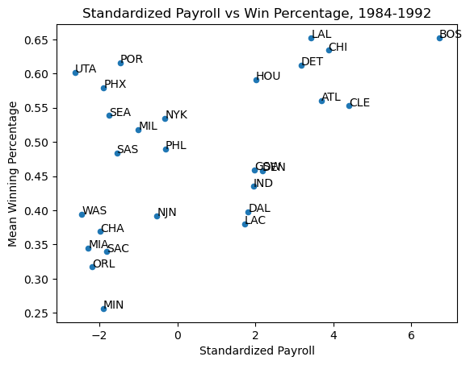

```python
##Extracting the rows from the table (NBA_Data)
team_data_period_1 = standardized_team_data.iloc[:151, [0,1,2,3,4,5,6,7,8,12]]

##Categorizing Data by team Abbreviation for easier processing
teams_1 = team_data_period_1['Abbreviation'].unique()

#processing the data, first by creating an array...
team_period_1 = []
for abbrev in teams_1:
    team_period_1.append(team_data_period_1[team_data_period_1.Abbreviation == abbrev])

##...then by creating a second array to hold the data.
team_data_1 = pd.concat(team_period_1)

#calculating the mean win percentage and Mean Standardized payroll for each team over this period
avg_standardized_payroll_per_team_1 = []
mean_winning_pct_per_team_1 = []
for abbrev in teams_1:
    avg_standardized_payroll_per_team_1.append(team_data_1.loc[team_data_1['Abbreviation'] == abbrev, 'Standardized Payroll'].mean())
    mean_winning_pct_per_team_1.append(team_data_1.loc[team_data_1['Abbreviation'] == abbrev, 'Win_Pct'].mean())

##Creating a dataframe to hold all the data as needed
team_avgs_period_1 = pd.DataFrame()
team_avgs_period_1['Team'] = teams_1
team_avgs_period_1['Standardized Payroll'] = avg_standardized_payroll_per_team_1
team_avgs_period_1['Mean Winning Percentage'] = mean_winning_pct_per_team_1

#plotting the data to show trends. (Should be no points because no data entered for this period yet.)
period_1_NBA = team_avgs_period_1.plot(kind = 'scatter', title = "Standardized Payroll vs Win Percentage, 1984-1992", x = 'Standardized Payroll', y = 'Mean Winning Percentage')
for idx, row in team_avgs_period_1.iterrows():
     period_1_NBA.annotate(row['Team'], (row['Standardized Payroll'], row['Mean Winning Percentage']))
```

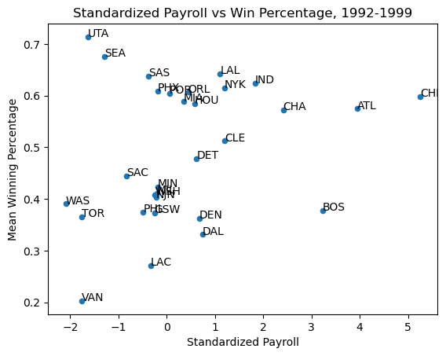

```python
##Extracting the rows from the table (NBA_Data)
team_data_period_2 = standardized_team_data.iloc[152:351, [0,1,2,3,4,5,6,7,8,12]]

##Categorizing Data by team Abbreviation for easier processing
teams_2 = team_data_period_2['Abbreviation'].unique()

#processing the data, first by creating an array with all data...
team_period_2 = []
for abbrev in teams_2:
    team_period_2.append(team_data_period_2[team_data_period_2.Abbreviation == abbrev])

##...then by creating a second array to structure the data.
team_data_2 = pd.concat(team_period_2)

#calculating the mean win percentage and Mean Standardized payroll for each team over this period
avg_standardized_payroll_per_team_2 = []
mean_winning_pct_per_team_2 = []
for abbrev in teams_2:
    avg_standardized_payroll_per_team_2.append(team_data_2.loc[team_data_2['Abbreviation'] == abbrev, 'Standardized Payroll'].mean())
    mean_winning_pct_per_team_2.append(team_data_2.loc[team_data_2['Abbreviation'] == abbrev, 'Win_Pct'].mean())
##Creating a dataframe to hold all the data as needed
team_avgs_period_2 = pd.DataFrame()
team_avgs_period_2['Team'] = teams_2
team_avgs_period_2['Standardized Payroll'] = avg_standardized_payroll_per_team_2
team_avgs_period_2['Mean Winning Percentage'] = mean_winning_pct_per_team_2

#plotting the data to show trends. (Should be no points because no data entered for this period yet.)
period_2_NBA = team_avgs_period_2.plot(kind = 'scatter', title = "Standardized Payroll vs Win Percentage, 1992-1999", x = 'Standardized Payroll', y = 'Mean Winning Percentage')
for idx, row in team_avgs_period_2.iterrows():
     period_2_NBA.annotate(row['Team'], (row['Standardized Payroll'], row['Mean Winning Percentage']))
```

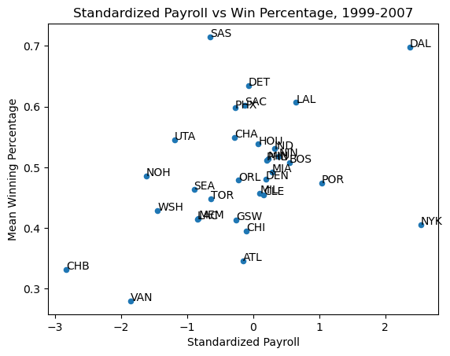

```python
##Extracting the rows from the table (NBA_Data)
team_data_period_3 = standardized_team_data.iloc[351:586, [0,1,2,3,4,5,6,7,8,12]]

##Categorizing Data by team Abbreviation for easier processing
teams_3 = team_data_period_3['Abbreviation'].unique()

#processing the data, first by creating an array...
team_period_3 = []
for abbrev in teams_3:
    team_period_3.append(team_data_period_3[team_data_period_3.Abbreviation == abbrev])

##...then by creating a second array to hold the data.
team_data_3 = pd.concat(team_period_3)

#calculating the mean win percentage and Mean Standardized payroll for each team over this period
avg_standardized_payroll_per_team_3 = []
mean_winning_pct_per_team_3 = []
for abbrev in teams_3:
    avg_standardized_payroll_per_team_3.append(team_data_3.loc[team_data_3['Abbreviation'] == abbrev, 'Standardized Payroll'].mean())
    mean_winning_pct_per_team_3.append(team_data_3.loc[team_data_3['Abbreviation'] == abbrev, 'Win_Pct'].mean())

##Creating a dataframe to hold all the data as needed
team_avgs_period_3 = pd.DataFrame()
team_avgs_period_3['Team'] = teams_3
team_avgs_period_3['Standardized Payroll'] = avg_standardized_payroll_per_team_3
team_avgs_period_3['Mean Winning Percentage'] = mean_winning_pct_per_team_3

#plotting the data to show trends. (Should be no points because no data entered for this period yet.)
period_3_NBA = team_avgs_period_3.plot(kind = 'scatter', title = "Standardized Payroll vs Win Percentage, 1999-2007", x = 'Standardized Payroll', y = 'Mean Winning Percentage')
for idx, row in team_avgs_period_3.iterrows():
     period_3_NBA.annotate(row['Team'], (row['Standardized Payroll'], row['Mean Winning Percentage']))
```

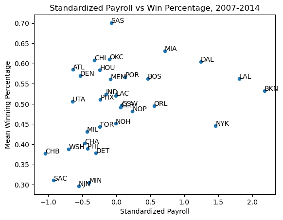

```python
##Extracting the rows from the table (NBA_Data)
team_data_period_4 = standardized_team_data.iloc[586:797, [0,1,2,3,4,5,6,7,8,12]]

##Categorizing Data by team Abbreviation for easier processing
teams_4 = team_data_period_4['Abbreviation'].unique()

#processing the data, first by creating an array...
team_period_4 = []
for abbrev in teams_4:
    team_period_4.append(team_data_period_4[team_data_period_4.Abbreviation == abbrev])

##...then by creating a second array to hold the data.
team_data_4 = pd.concat(team_period_4)

#calculating the mean win percentage and Mean Standardized payroll for each team over this period
avg_standardized_payroll_per_team_4 = []
mean_winning_pct_per_team_4 = []
for abbrev in teams_4:
    avg_standardized_payroll_per_team_4.append(team_data_4.loc[team_data_4['Abbreviation'] == abbrev, 'Standardized Payroll'].mean())
    mean_winning_pct_per_team_4.append(team_data_4.loc[team_data_4['Abbreviation'] == abbrev, 'Win_Pct'].mean())

##Creating a dataframe to hold all the data as needed
team_avgs_period_4 = pd.DataFrame()
team_avgs_period_4['Team'] = teams_4
team_avgs_period_4['Standardized Payroll'] = avg_standardized_payroll_per_team_4
team_avgs_period_4['Mean Winning Percentage'] = mean_winning_pct_per_team_4

#plotting the data to show trends. (Should be no points because no data entered for this period yet.)
period_4_NBA = team_avgs_period_4.plot(kind = 'scatter', title = "Standardized Payroll vs Win Percentage, 2007-2014", x = 'Standardized Payroll', y = 'Mean Winning Percentage')
for idx, row in team_avgs_period_4.iterrows():
     period_4_NBA.annotate(row['Team'], (row['Standardized Payroll'], row['Mean Winning Percentage']))
```

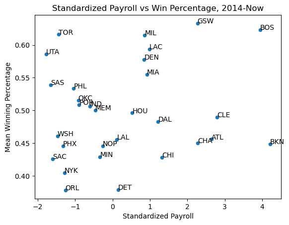

```python
##Extracting the rows from the table (NBA_Data)
team_data_period_5 = standardized_team_data.iloc[797:, [0,1,2,3,4,5,6,7,8,12]]

##Categorizing Data by team Abbreviation for easier processing
teams_5 = team_data_period_5['Abbreviation'].unique()

#processing the data, first by creating an array...
team_period_5 = []
for abbrev in teams_5:
    team_period_5.append(team_data_period_5[team_data_period_5.Abbreviation == abbrev])

##...then by creating a second array to hold the data.
team_data_5 = pd.concat(team_period_5)

#calculating the mean win percentage and Mean Standardized payroll for each team over this period
avg_standardized_payroll_per_team_5 = []
mean_winning_pct_per_team_5 = []
for team in teams_5:
    avg_standardized_payroll_per_team_5.append(team_data_5.loc[team_data_5['Abbreviation'] == team, 'Standardized Payroll'].mean())
    mean_winning_pct_per_team_5.append(team_data_5.loc[team_data_5['Abbreviation'] == team, 'Win_Pct'].mean())

##Creating a dataframe to hold all the data as needed
team_avgs_period_5 = pd.DataFrame()
team_avgs_period_5['Team'] = teams_5
team_avgs_period_5['Standardized Payroll'] = avg_standardized_payroll_per_team_5
team_avgs_period_5['Mean Winning Percentage'] = mean_winning_pct_per_team_5

#plotting the data to show trends. (Should be no points because no data entered for this period yet.)
period_5_NBA = team_avgs_period_5.plot(kind = 'scatter', title = "Standardized Payroll vs Win Percentage, 2014-Now", x = 'Standardized Payroll', y = 'Mean Winning Percentage')
for idx, row in team_avgs_period_5.iterrows():
     period_5_NBA.annotate(row['Team'], (row['Standardized Payroll'], row['Mean Winning Percentage']))
```

### Part 6: Analyzing the data across time

Now that we have collected all the needed data and performed some cursory analysis and standardization, we need to be able to analyze our data through time. This will give us a better idea of how things have changed from 1985 to now.

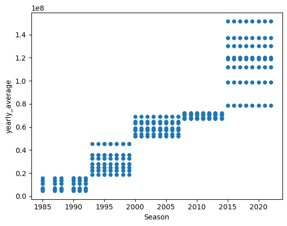

```python
standardized_team_data.plot(kind = 'scatter', x = 'Season', y = 'yearly_average')
```

However, we don't just want to look at the league as a whole. Let's split the league into east and west, analyzing how each conference spent over the 40 year study period.

To do this, we will make a plot known as a Violin Plot, which can be found in python's Seaborn Module.

```python
import seaborn
```

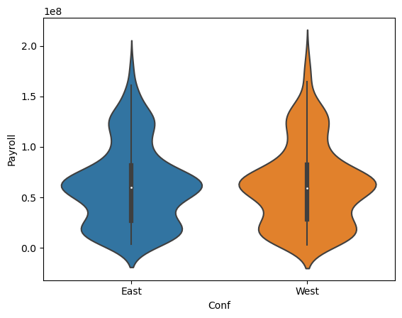

```python
seaborn.violinplot(x = standardized_team_data['Conf'], y = standardized_team_data['Payroll'])
```

Let's try to actually see how much more wins teams get by paying more. We will do this using the Statsmodels API.

```python
import statsmodels.api as sm
```

```python
model = sm.OLS( standardized_team_data['Win_Pct'], standardized_team_data['Payroll'])
```

```python
regression = model.fit()
```

```python
print(regression.summary())
```

```
                                 OLS Regression Results
=======================================================================================
Dep. Variable:                Win_Pct   R-squared (uncentered):                   0.669
Model:                            OLS   Adj. R-squared (uncentered):              0.669
Method:                 Least Squares   F-statistic:                              2094.
Date:                Thu, 17 Aug 2023   Prob (F-statistic):                   5.41e-251
Time:                        13:30:29   Log-Likelihood:                         -225.78
No. Observations:                1037   AIC:                                      453.6
Df Residuals:                    1036   BIC:                                      458.5
Df Model:                           1
Covariance Type:            nonrobust
==============================================================================
                 coef    std err          t      P>|t|      [0.025      0.975]
------------------------------------------------------------------------------
Payroll     5.788e-09   1.26e-10     45.762      0.000    5.54e-09    6.04e-09
==============================================================================
Omnibus:                       18.683   Durbin-Watson:                   0.324
Prob(Omnibus):                  0.000   Jarque-Bera (JB):               16.475
Skew:                          -0.250   Prob(JB):                     0.000265
Kurtosis:                       2.637   Cond. No.                         1.00
==============================================================================

Notes:
[1] R² is computed without centering (uncentered) since the model does not contain a constant.
[2] Standard Errors assume that the covariance matrix of the errors is correctly specified.
```

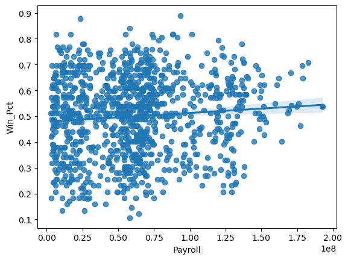

```python
seaborn.regplot(y = standardized_team_data['Win_Pct'], x = standardized_team_data['Payroll'], fit_reg = True)
```

We can see, from the analysis that the number of wins isn't really determined by payroll. However, we can perform further analysis to see how much payroll should be considered when planning how to best build a team.

Let's revise our model so that we base our recommendations on Conference and Payroll.

```python
revised_model = sm.OLS.from_formula('Win_Pct ~ Conf + Payroll', standardized_team_data)
```

```python
revised_regression = revised_model.fit()
```

```python
print(revised_regression.summary())
```

```
                            OLS Regression Results
==============================================================================
Dep. Variable:                Win_Pct   R-squared:                       0.015
Model:                            OLS   Adj. R-squared:                  0.013
Method:                 Least Squares   F-statistic:                     7.986
Date:                Thu, 17 Aug 2023   Prob (F-statistic):           0.000362
Time:                        13:30:29   Log-Likelihood:                 479.52
No. Observations:                1037   AIC:                            -953.0
Df Residuals:                    1034   BIC:                            -938.2
Df Model:                           2
Covariance Type:            nonrobust
================================================================================
                   coef    std err          t      P>|t|      [0.025      0.975]
--------------------------------------------------------------------------------
Intercept        0.4658      0.010     46.900      0.000       0.446       0.485
Conf[T.West]     0.0266      0.009      2.811      0.005       0.008       0.045
Payroll       3.359e-10   1.19e-10      2.833      0.005    1.03e-10    5.69e-10
==============================================================================
Omnibus:                       54.234   Durbin-Watson:                   0.970
Prob(Omnibus):                  0.000   Jarque-Bera (JB):               25.997
Skew:                          -0.184   Prob(JB):                     2.26e-06
Kurtosis:                       2.317   Cond. No.                     1.84e+08
==============================================================================

Notes:
[1] Standard Errors assume that the covariance matrix of the errors is correctly specified.
[2] The condition number is large, 1.84e+08. This might indicate that there are
strong multicollinearity or other numerical problems.
```

As a team based in Seattle, you will be playing, more likely than not, in the Western Conference of the NBA. Therefore, the link between conference, payroll, and win percentage is cause for jubilation as it shows that Western teams can win more with smart spending.

But, just as a safeguard, you decide to run one final set of analyses on how payroll impacts wins. You decide to create a regression line relating payroll to expected wins so that you can see how many more wins every dollar generates.

To do this, we first need to import NumPy, a numerical powerhouse of a python module. We also need MatPlotLib to be able to generate the plots we want.

```python
import numpy as np
import matplotlib.pyplot as plt
```

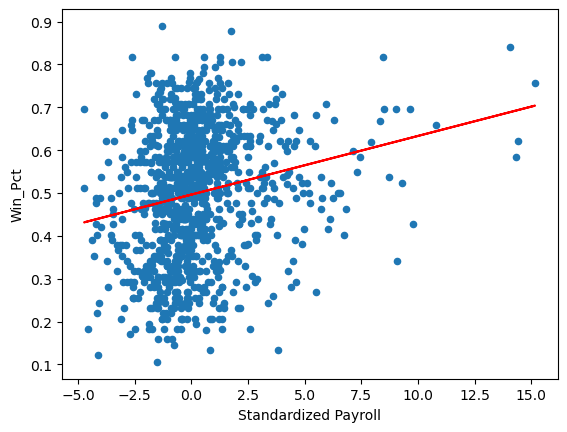

```python
expected_wins = standardized_team_data.plot(kind = 'scatter', x = 'Standardized Payroll', y = 'Win_Pct')
m, b = np.polyfit(standardized_team_data['Standardized Payroll'], standardized_team_data['Win_Pct'], deg = 1)
plt.plot(standardized_team_data['Standardized Payroll'], m*standardized_team_data['Standardized Payroll']+b, color = 'red')
```

Now that we have our graph, with the line indicating a positive correlation whereby more money leads to more wins, we can actually see the model. Let's print our model parameters, just to get an idea of the impact.

```python
m*100
```

```
1.3684489641085293
```

```python
b*100
```

```
49.64897363934623
```

So, after printing out the model parameters, we get that $Expected Wins = 49 + 1*(Standardized Payroll)$. What this tells us is that for every unit increase in standardized payroll, we can expect to win $1\%$ more games in a season.

Now, to make our final recommendation, we need to see which teams were most efficient (i.e. highest win percentage with lowest payroll)

```python
standardized_team_data = standardized_team_data.drop(columns = ['bins'])
```

```python
standardized_team_data['Expected Win Percentage'] = (100*b) + (100*m)*standardized_team_data['Standardized Payroll']
standardized_team_data['Win_Pct'] = standardized_team_data['Win_Pct'] * 100
```

```python
standardized_team_data['Efficiency'] = standardized_team_data['Win_Pct']-standardized_team_data['Expected Win Percentage']
```

Now, just for comparison sake, we will plot 1 team: the previous Seattle Franchise and Study its efficiency over this period. Since the franchise is in the same city as your new franchise, you can analyze how good they were to understand how you should do.

```python
plot_teams = standardized_team_data[(standardized_team_data['Abbreviation'] == 'SEA')]
```

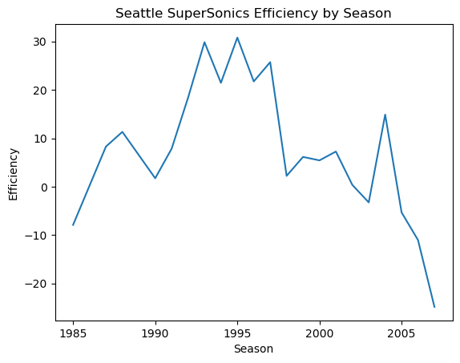

```python
plt.plot('Season', 'Efficiency', data = plot_teams)
plt.xlabel('Season')
plt.ylabel('Efficiency')
plt.title("Seattle SuperSonics Efficiency by Season")
```

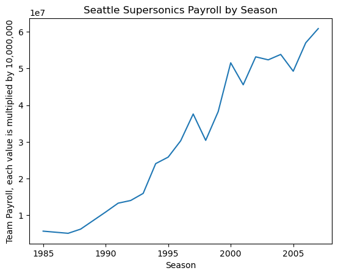

```python
plt.plot('Season', 'Payroll', data = plot_teams)
plt.xlabel('Season')
plt.ylabel('Team Payroll, each value is multiplied by 10,000,000')
plt.title("Seattle Supersonics Payroll by Season")
```

Let's now compile all of the major analyses we have done, perform one final analysis, and make a recommendation.

Firstly, let's compare the two regression models we generated.

```python
print("Original Model: Payroll Only")
print(regression.summary())
print("-------------------------------------------")
print("Revised Model: Payroll and Conference")
print(revised_regression.summary())
```

```
Original Model: Payroll Only
                                 OLS Regression Results
=======================================================================================
Dep. Variable:                Win_Pct   R-squared (uncentered):                   0.669
Model:                            OLS   Adj. R-squared (uncentered):              0.669
Method:                 Least Squares   F-statistic:                              2094.
Date:                Thu, 17 Aug 2023   Prob (F-statistic):                   5.41e-251
Time:                        13:30:30   Log-Likelihood:                         -225.78
No. Observations:                1037   AIC:                                      453.6
Df Residuals:                    1036   BIC:                                      458.5
Df Model:                           1
Covariance Type:            nonrobust
==============================================================================
                 coef    std err          t      P>|t|      [0.025      0.975]
------------------------------------------------------------------------------
Payroll     5.788e-09   1.26e-10     45.762      0.000    5.54e-09    6.04e-09
==============================================================================
Omnibus:                       18.683   Durbin-Watson:                   0.324
Prob(Omnibus):                  0.000   Jarque-Bera (JB):               16.475
Skew:                          -0.250   Prob(JB):                     0.000265
Kurtosis:                       2.637   Cond. No.                         1.00
==============================================================================

Notes:
[1] R² is computed without centering (uncentered) since the model does not contain a constant.
[2] Standard Errors assume that the covariance matrix of the errors is correctly specified.
-------------------------------------------
Revised Model: Payroll and Conference
                            OLS Regression Results
==============================================================================
Dep. Variable:                Win_Pct   R-squared:                       0.015
Model:                            OLS   Adj. R-squared:                  0.013
Method:                 Least Squares   F-statistic:                     7.986
Date:                Thu, 17 Aug 2023   Prob (F-statistic):           0.000362
Time:                        13:30:30   Log-Likelihood:                 479.52
No. Observations:                1037   AIC:                            -953.0
Df Residuals:                    1034   BIC:                            -938.2
Df Model:                           2
Covariance Type:            nonrobust
================================================================================
                   coef    std err          t      P>|t|      [0.025      0.975]
--------------------------------------------------------------------------------
Intercept        0.4658      0.010     46.900      0.000       0.446       0.485
Conf[T.West]     0.0266      0.009      2.811      0.005       0.008       0.045
Payroll       3.359e-10   1.19e-10      2.833      0.005    1.03e-10    5.69e-10
==============================================================================
Omnibus:                       54.234   Durbin-Watson:                   0.970
Prob(Omnibus):                  0.000   Jarque-Bera (JB):               25.997
Skew:                          -0.184   Prob(JB):                     2.26e-06
Kurtosis:                       2.317   Cond. No.                     1.84e+08
==============================================================================

Notes:
[1] Standard Errors assume that the covariance matrix of the errors is correctly specified.
[2] The condition number is large, 1.84e+08. This might indicate that there are
strong multicollinearity or other numerical problems.
```

Then, let's print our parameters for regression.

```python
m*100
```

```
1.3684489641085293
```

```python
b*100
```

```
49.64897363934623
```

### Part 7: Gradient Descent

In this part, we will use an algorithm called Batch Gradient Descent in order to make the most accurate model for the period being studied. Furthermore, we will use the gradient descent model generated to make a final recommendation based on the assumption that we want to win a record number of games: $74/82$ or $90.24\%$

```python
# Univariate
X = 2*np.random.rand(100,1)
```

```python
y = 49 + 1*X + np.random.randn(100,1)
```

The above two lines of code have just generated a placeholder model. This model is just a guess for what the actual model will be like.

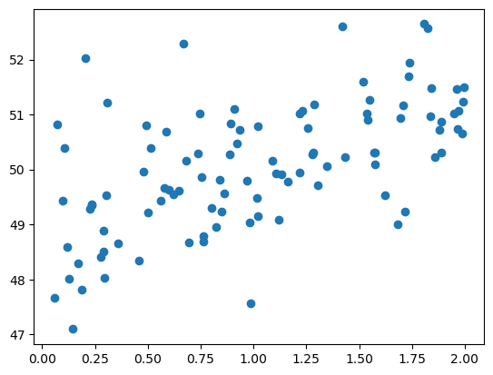

```python
plt.scatter(X,y)
```

From the plot of the data, we can see that X and y share a positive correlation, and a strong one at that. This means that our initial guess is a good one and the actual model will be something similar.

```python
#since there are 2 variables theta_0 and theta_1, we need two columns for the x-values
X_b = np.c_[np.ones((100,1)),X]
```

```python
eta = 0.1
n_iterations = 1000
m = 100 #note, this is different from the 'm' representing the slope of the linear regression line
```

```python
#As we are making random guesses for X and Y, so we must do the same for the Theta values
theta = np.random.randn(2,1)
```

```python
for i in range(n_iterations):
    gradients = 2/m * X_b.T.dot(X_b.dot(theta)-y)
    theta = theta - eta*gradients
```

```python
theta
```

```
array([[48.91639557],
       [ 1.13151478]])
```

```python
# Gradient Descent: We need to test theta values as we go, deciding whether we need to increase or decrease them to get the most optimal estimate
def grad_descent(X,y,T,alpha):
    m, n = X.shape
    theta = np.zeros(n)
    f = np.zeros(T)
    for i in range(T):
        f[i] = 0.5*np.linalg.norm(X.dot(theta)-y)**2
        g = np.transpose(X).dot(X.dot(theta)-y)
        theta = theta - alpha*g
    return(theta,f)
```

```python
T = 500 #Number of timesteps (How many iterations?)
alpha = 0.0001 #the learning rate (How quickly does the model improve?)
theta,loss = grad_descent(X,y,T,alpha)
```

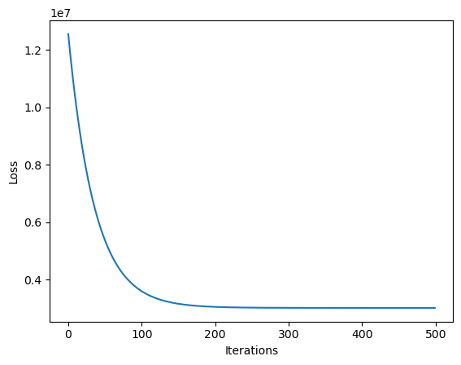

```python
plt.plot(range(T),loss)
plt.ylabel("Loss")
plt.xlabel("Iterations")
plt.show()
```

As we can see from the loss curve, we can tell that our model got better as time went on. Now, with the Gradient Descent completed, it's time to make the final recommendation.

Our model is as follows: $Win Percentage = 48.76264002+1.05357897*Payroll$

### Part 8: The final recommendation

You were hired by the team to let them know how much payroll they would need in order to win an NBA-record 74 games from the standard 82 game season. Calculation led to the determination that this win percentage would be approximately $90\%$.

Armed with your model, you plug in 90 for win percentage and attempt to solve.

What this yields is $ 90 = 48.76264002+1.05357897*Payroll$, which you solve, using basic Python.

```python
payroll_reqd = ((90-48.76264002)/1.05357897)*1000000
```

```python
payroll_reqd
```

```
39140264.90107334
```

Because the typical American Currency only has Dollars and Cents (2 decimal places), you need to round your solution before proposing it to the ownership group.

```python
round(payroll_reqd, 2)
```

```
39140264.9
```

At long last, with all analysis complete, you write a letter to the ownership group with your recommendation of the payroll they should use to get their target of 74 wins.

Dear Ownership Group,

As the Director of Operations for our Seattle NBA Franchise, I wanted to reach out and share some insights that I believe could be helpful as we look ahead to the upcoming season.

One of our key goals this year is to achieve an NBA-record 74 wins out of the 82 game season. In order to accomplish this goal, it is crucial that we carefully consider our payroll and how we allocate our resources.

After extensive analysis and consideration, I recommend that we aim for a maximum p of $\$ 39, 140, 264.90$. This amount will allow us to attract and retain top talent while still remaining fiscally responsible and maximizing our chances of success on the court.

I understand that this may seem like a significant constraint, but I believe that with careful planning and execution, we can still achieve our goals while staying within this budget. I look forward to working together to make this season a success.

Sincerely,

Director of Operations